# Ecotourism Tutorial

Joining occurrence, weather, and tourism data

Author

Mahjabin Siddika Oyshi

## Objectives

In this tutorial you will work with orchid sightings from the `ecotourism` package, and link them to weather and tourism data. We will focus on Western Australia during September, when many orchids are flowering.

By the end you should be able to:

- filter occurrence records by state and month
- join occurrence data to daily weather using `ws_id` and `date`
- join occurrence data to quarterly tourism counts
- check how complete the joined data is

## Preparation

We will use four linked datasets:

- `orchids`: orchid occurrence records (2014–2024)
- `weather`: daily weather by station
- `tourism_quarterly`: quarterly domestic visitor counts by region
- `tourism_region`: tourism region names with coordinates and `ws_id`

## Exercises

### Question 1 — Western Australia, September

In this question you will look at orchid sightings in Western Australia during September.

1. Filter `orchids` to rows where `obs_state == "Western Australia"` and `month == 9`.
2. Join these rows to `weather` using `ws_id` and `date`.
3. Count
   - how many sightings you have in total
   - how many of them have a non‑missing `max` (daily maximum temperature)

What does this tell you about how complete the weather data is for these sightings?

#### Solution 1

```r
wa_sep <- orchids |>
  dplyr::filter(
    obs_state == "Western Australia",
    month == 9
  )

wa_sep_weather <- wa_sep |>
  dplyr::left_join(weather, by = c("ws_id", "date"))

# total September sightings in WA
nrow(wa_sep)
```

```
[1] 14911
```

```r
# sightings with weather data
sum(!is.na(wa_sep_weather$max))
```

```
[1] 1012
```

```r
# proportion missing max temperature
mean(is.na(wa_sep_weather$max))
```

```
[1] 0.9321306
```

Only about 7% of September orchid sightings in Western Australia have a recorded maximum temperature, so the weather data is very incomplete. This suggests gaps in the weather records rather than a lack of orchid activity, and shows why updating the weather part of the package is important.

### Question 2 — Adding tourism

Now bring in the tourism data.

1. Start from the Western Australia September orchid data you used in Question 1.
2. Join it to the `tourism_total` table using `ws_id`, `year`, and `quarter`. Remember that September is in quarter 3.
3. For Western Australia, report:
   - the total number of September orchid sightings
   - the average `total_trips`
   - the proportion of sightings that have a non‑missing `max` temperature.

What do these numbers suggest about how much tourism and weather information is available for the places where orchids are being recorded?

#### Solution 2

```r
# Western Australia, September orchids with quarter
wa_sep_q <- orchids |>
  dplyr::filter(
    obs_state == "Western Australia",
    month == 9
  ) |>
  dplyr::mutate(quarter = 3L)

# join tourism totals
wa_sep_tour <- wa_sep_q |>
  dplyr::left_join(
    tourism_total,
    by = c("ws_id", "year", "quarter")
  )

# join weather again so we still have max temperature
wa_sep_full <- wa_sep_tour |>
  dplyr::left_join(weather, by = c("ws_id", "date"))

summary_q2 <- wa_sep_full |>
  dplyr::summarise(
    n_sightings   = dplyr::n(),
    mean_trips    = mean(total_trips, na.rm = TRUE),
    prop_with_max = mean(!is.na(max))
  )

summary_q2
```

```
# A tibble: 1 × 3
  n_sightings mean_trips prop_with_max
        <int>      <dbl>         <dbl>
1       14911       32.7        0.0679
```

There are 14,911 September orchid sightings in Western Australia, but the average tourism trip count at those stations is only about 33. Just under 7% of sightings have a recorded maximum temperature. This tells us that most orchid records sit in areas with relatively low reported tourism, and weather data is still very patchy for these locations.

### Question 3 — Sightings vs tourism

Using the joined data from Question 2:

1. For each year in Western Australia, work out:
   - total September orchid sightings
   - average `total_trips`.
2. Make a scatter plot with `total_trips` on the x‑axis and total orchid sightings on the y‑axis.

Does it look like years with more visitors also have more recorded orchid sightings? How might observer effort explain any pattern you see?

#### Solution 3

```r
# Western Australia, September orchids with quarter
wa_sep_q <- orchids |>
  dplyr::filter(
    obs_state == "Western Australia",
    month == 9
  ) |>
  dplyr::mutate(quarter = 3L)

# join tourism totals
wa_sep_tour <- wa_sep_q |>
  dplyr::left_join(
    tourism_total,
    by = c("ws_id", "year", "quarter")
  )

# (optional) join weather to keep using all three tables
wa_sep_full <- wa_sep_tour |>
  dplyr::left_join(weather, by = c("ws_id", "date"))

# yearly totals for WA, September
yearly_wa <- wa_sep_tour |>
  dplyr::group_by(year) |>
  dplyr::summarise(
    n_sightings = dplyr::n(),
    mean_trips  = mean(total_trips, na.rm = TRUE),
    .groups = "drop"
  )

yearly_wa
```

```
# A tibble: 11 × 3
    year n_sightings mean_trips
   <dbl>       <int>      <dbl>
 1  2014         372       13.4
 2  2015         158       25.3
 3  2016         391       24.2
 4  2017         424       31.2
 5  2018         773       34.7
 6  2019         599       48.7
 7  2020        1488       29.9
 8  2021        1350       26.2
 9  2022        1899       41.7
10  2023        3329      NaN
11  2024        4128      NaN
```

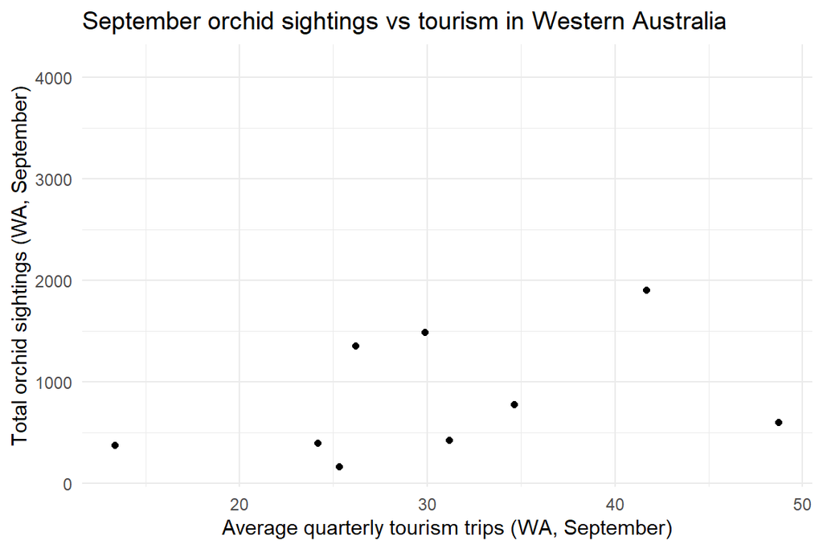

```r
ggplot(yearly_wa,
       aes(x = mean_trips, y = n_sightings)) +
  geom_point() +
  labs(
    x = "Average quarterly tourism trips (WA, September)",
    y = "Total orchid sightings (WA, September)",
    title = "September orchid sightings vs tourism in Western Australia"
  ) +
  theme_minimal()
```

Overall, there is a loose positive relationship between tourism and orchid sightings: years with higher average trip counts often have more recorded September sightings in Western Australia.